# Unicorn Company Analysis

Kundana Mandapaka

In business, a unicorn is a startup company valued at over US$1 billion which is privately owned and not listed on a share market. This dataset consists of unicorn companies and startups across the globe as of November 2021, including country of origin, sector, select investors, and valuation of each unicorn.

### Scenario

You have been hired as a data analyst for a global venture capital firm that specializes in investing in high-potential start-ups. Your manager is interested in understanding the current landscape of unicorn companies to identify emerging trends and investment opportunities.

Using the unicorn dataset provided, your task is to analyze various factors such as the geographical distribution of unicorns, industry sectors with the highest valuations, funding patterns, and key investors. Your goal is to provide insights that can guide the firm’s investment strategy, highlighting regions and industries with the most growth potential and identifying key investors who frequently back successful unicorns. This analysis will help the firm make data-driven decisions on where to allocate their resources for maximum return on investment.

### Purpose of the Project

To provide valuable insights into the dynamic landscape of unicorn companies for a global venture capital firm. The goal is to identify emerging trends, investment opportunities, and key factors contributing to the success of these companies. By analyzing the geography, industry, funding patterns, and key investors, the aim is to guide the firm’s investment strategy and optimize resource allocation for maximum returns. The insights will be presented through an interactive dashboard, showcasing the distribution and characteristics of unicorn companies worldwide.

### Data Preperation

```r
#import libraries
library(knitr)
library(kableExtra)
library(tidyverse)
library(lubridate)
library(skimr)
library(janitor)
library(ggplot2)
```

```r
companies_df <- read.csv("~/Documents/projects/unicorn/Unicorn_Companies.csv")
```

### Data Cleaning

#### Inspecting the data

```r
str(companies_df)
```

```
'data.frame':   1074 obs. of  18 variables:
 $ Company         : chr  "Bytedance" "SpaceX" "SHEIN" "Stripe" ...
 $ Valuation...B.  : int  180 100 100 95 46 40 40 39 38 38 ...
 $ Date.Joined     : chr  "4/7/17" "12/1/12" "7/3/18" "1/23/14" ...
 $ Year.Joined     : int  2017 2012 2018 2014 2011 2018 2019 2014 2017 2019 ...
 $ Month.Joined    : int  4 12 7 1 12 1 5 12 12 2 ...
 $ Day.Joined      : int  7 1 3 23 12 8 2 30 20 5 ...
 $ Industry        : chr  "Artificial intelligence" "Other" "E-commerce & direct-to-consumer" "Fintech" ...
 $ City            : chr  "Beijing" "Hawthorne" "Shenzhen" "San Francisco" ...
 $ Country         : chr  "China" "United States" "China" "United States" ...
 $ Continent       : chr  "Asia" "North America" "Asia" "North America" ...
 $ Years.to.Unicorn: int  5 10 10 4 6 6 7 2 2 6 ...
 $ Year.Founded    : int  2012 2002 2008 2010 2005 2012 2012 2012 2015 2013 ...
 $ Funding...B.    : num  8 7 2 2 4 0.572 2 3 14 3 ...
 $ Investor.1      : chr  "Sequoia Capital China" "Founders Fund" "Tiger Global Management" "Khosla Ventures" ...
 $ Investor.2      : chr  " SIG Asia Investments" " Draper Fisher Jurvetson" " Sequoia Capital China" " LowercaseCapital" ...
 $ Investor.3      : chr  " Sina Weibo" " Rothenberg Ventures" " Shunwei Capital Partners" " capitalG" ...
 $ Investor.4      : chr  " Softbank Group" "" "" "" ...
 $ Investors       : chr  "Sequoia Capital China, SIG Asia Investments, Sina Weibo, Softbank Group" "Founders Fund, Draper Fisher Jurvetson, Rothenberg Ventures" "Tiger Global Management, Sequoia Capital China, Shunwei Capital Partners" "Khosla Ventures, LowercaseCapital, capitalG" ...
```

```r
summary(companies_df)
```

```
   Company          Valuation...B.    Date.Joined         Year.Joined    Month.Joined
 Length:1074        Min.   :  1.000   Length:1074        Min.   :2007   Min.   : 1.00
 Class :character   1st Qu.:  1.000   Class :character   1st Qu.:2019   1st Qu.: 3.00
 Mode  :character   Median :  2.000   Mode  :character   Median :2021   Median : 6.00
                    Mean   :  3.455                      Mean   :2020   Mean   : 6.35
                    3rd Qu.:  3.000                      3rd Qu.:2021   3rd Qu.: 9.00
                    Max.   :180.000                      Max.   :2022   Max.   :12.00
   Day.Joined      Industry             City             Country           Continent
 Min.   : 1.00   Length:1074        Length:1074        Length:1074        Length:1074
 1st Qu.: 9.00   Class :character   Class :character   Class :character   Class :character
 Median :16.00   Mode  :character   Mode  :character   Mode  :character   Mode  :character
 Mean   :15.82
 3rd Qu.:23.00
 Max.   :31.00
 Years.to.Unicorn  Year.Founded   Funding...B.      Investor.1         Investor.2
 Min.   :-4.000   Min.   :1919   Min.   : 0.0000   Length:1074        Length:1074
 1st Qu.: 4.000   1st Qu.:2011   1st Qu.: 0.2240   Class :character   Class :character
 Median : 6.000   Median :2014   Median : 0.3735   Mode  :character   Mode  :character
 Mean   : 7.001   Mean   :2013   Mean   : 0.5573
 3rd Qu.: 9.000   3rd Qu.:2016   3rd Qu.: 0.6030
 Max.   :98.000   Max.   :2021   Max.   :14.0000
  Investor.3         Investor.4         Investors
 Length:1074        Length:1074        Length:1074
 Class :character   Class :character   Class :character
 Mode  :character   Mode  :character   Mode  :character
```

```r
head(companies_df)
```

|  | Company | Valuation...B. | Date.Joined | Year.Joined | Month.Joined | Day.Joined | Industry | City | Country | Continent | Years.to.Unicorn | Year.Founded | Funding...B. | Investor.1 | Investor.2 | Investor.3 | Investor.4 | Investors |
| --- | --- | --- | --- | --- | --- | --- | --- | --- | --- | --- | --- | --- | --- | --- | --- | --- | --- | --- |
| 1 | Bytedance | 180 | 4/7/17 | 2017 | 4 | 7 | Artificial intelligence | Beijing | China | Asia | 5 | 2012 | 8.000 | Sequoia Capital China | SIG Asia Investments | Sina Weibo | Softbank Group | Sequoia Capital China, SIG Asia Investments, Sina Weibo, Softbank Group |
| 2 | SpaceX | 100 | 12/1/12 | 2012 | 12 | 1 | Other | Hawthorne | United States | North America | 10 | 2002 | 7.000 | Founders Fund | Draper Fisher Jurvetson | Rothenberg Ventures |  | Founders Fund, Draper Fisher Jurvetson, Rothenberg Ventures |
| 3 | SHEIN | 100 | 7/3/18 | 2018 | 7 | 3 | E-commerce & direct-to-consumer | Shenzhen | China | Asia | 10 | 2008 | 2.000 | Tiger Global Management | Sequoia Capital China | Shunwei Capital Partners |  | Tiger Global Management, Sequoia Capital China, Shunwei Capital Partners |
| 4 | Stripe | 95 | 1/23/14 | 2014 | 1 | 23 | Fintech | San Francisco | United States | North America | 4 | 2010 | 2.000 | Khosla Ventures | LowercaseCapital | capitalG |  | Khosla Ventures, LowercaseCapital, capitalG |
| 5 | Klarna | 46 | 12/12/11 | 2011 | 12 | 12 | Fintech | Stockholm | Sweden | Europe | 6 | 2005 | 4.000 | Institutional Venture Partners | Sequoia Capital | General Atlantic |  | Institutional Venture Partners, Sequoia Capital, General Atlantic |
| 6 | Canva | 40 | 1/8/18 | 2018 | 1 | 8 | Internet software & services | Surry Hills | Australia | Oceania | 6 | 2012 | 0.572 | Sequoia Capital China | Blackbird Ventures | Matrix Partners |  | Sequoia Capital China, Blackbird Ventures, Matrix Partners |

### Exploratory Analysis

#### 1. Sector-wise Distribution of Unicorn Companies

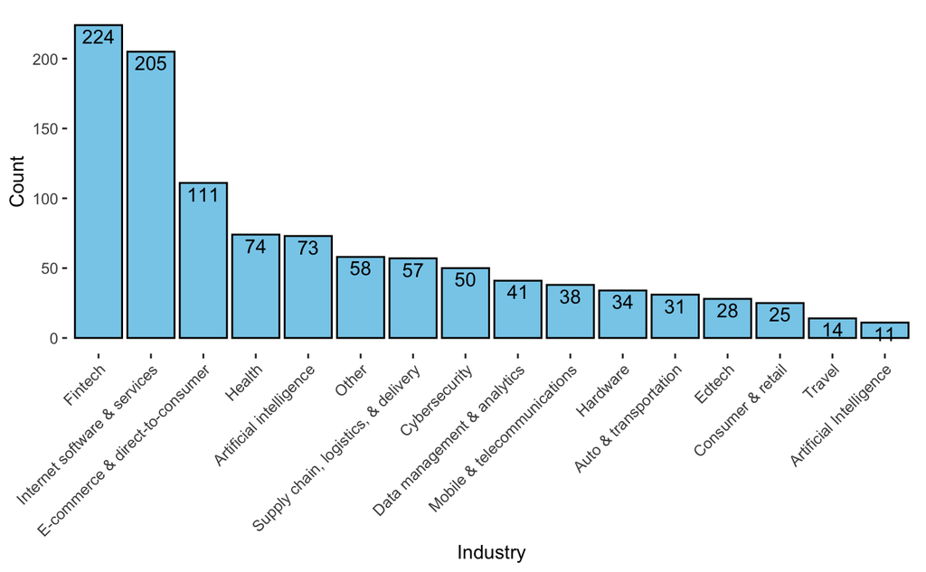

```r
# Calculate the count of unicorn startups by sector
sector_counts <- table(companies_df$Industry)

# Create a data frame for plotting with sector counts
plot_data <- data.frame(Industry = names(sector_counts),
                        count = as.numeric(sector_counts))

# Create a bar chart showing unicorn startups by sector in descending order with data labels
ggplot(plot_data, aes(x = reorder(Industry, -count), y = count)) +
  geom_bar(stat = "identity", fill = "skyblue", color = "black") +
  geom_text(aes(label = count), vjust = 1.3, color = "black") +
  labs(x = "Industry", y = "Count") +
  theme(panel.background = element_blank(),  # Remove background
        panel.grid.major = element_blank(),  # Remove major gridlines
        panel.grid.minor = element_blank(),  # Remove minor gridlines
        axis.text.x = element_text(angle = 45, hjust = 1))  # Adjust x-axis text
```

- Fintech and Internet software & services are leading in the number of unicorn companies, with 224 and 205 respectively.
- These sectors show a substantial lead over traditional industries like Consumer & retail and travel.
- The dominance of Fintech and Internet software & services underscores their popularity and growth in the unicorn startup space.
- This trend highlights a clear preference for investment and expansion in these booming sectors over more traditional industries.

#### 2. Global Distribution of Unicorn Companies by Continent

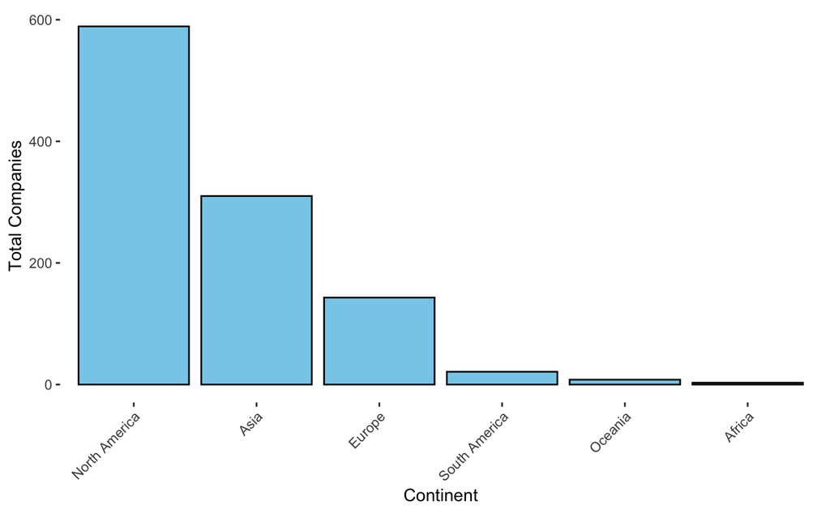

```r
# Group by continent and count the number of companies
continent_counts <- companies_df %>%
  group_by(Continent) %>%
  summarise(total_companies = n()) %>%
  arrange(desc(total_companies))  # Arrange in descending order

# Reorder the Continent factor levels based on total companies count
continent_counts$Continent <- factor(continent_counts$Continent, levels = continent_counts$Continent)

# Create a bar chart showing total companies by continent in descending order
ggplot(continent_counts, aes(x = Continent, y = total_companies, fill = Continent)) +
  geom_bar(stat = "identity", fill = "skyblue", color = "black") +
  labs( x = "Continent", y = "Total Companies") +
  theme(panel.background = element_blank(),  # Remove background
        panel.grid.major = element_blank(),  # Remove major gridlines
        panel.grid.minor = element_blank(),  # Remove minor gridlines
        axis.text.x = element_text(angle = 45, hjust = 1))  # Adjust x-axis text
```

- North America leads globally with the most unicorn companies (589), primarily in the United States, notably in Silicon Valley.
- Asia and Europe also have significant numbers of unicorn companies, driven by tech hubs in countries like China, India, and various European cities.
- Africa has the fewest unicorn companies among the continents studied, reflecting challenges in its tech ecosystem compared to other regions.

#### 3. Year-wise Summary of Unicorn Company Joinings

```r
# Group by Year Joined and count the number of companies
yearly_counts <- companies_df %>%
  group_by(Year.Joined) %>%
  summarise(total_companies = n()) %>%
  arrange(Year.Joined)  # Arrange by Year_Joined if not already sorted

# Display the yearly counts as a table
kable(yearly_counts) %>%
  kable_styling(full_width = FALSE)
```

| Year.Joined | total_companies |
| --- | --- |
| 2007 | 1 |
| 2011 | 2 |
| 2012 | 4 |
| 2013 | 3 |
| 2014 | 13 |
| 2015 | 35 |
| 2016 | 21 |
| 2017 | 44 |
| 2018 | 103 |
| 2019 | 104 |
| 2020 | 108 |
| 2021 | 520 |
| 2022 | 116 |

```r
NA
```

### Valuation Analysis

#### 1. Average market valuation

```r
average_valuation <- companies_df %>%
  summarise(avg_valuation = mean(Valuation...B., na.rm = TRUE))
average_valuation
```

| avg_valuation |
| --- |
| 3.455307 |

```r
NA
```

#### 2. Average valuation for companies accross each country

```r
country_summary <- companies_df %>%
  group_by(Country) %>%
  summarise(
    num_companies = n(),
    avg_country_valuation = mean(Valuation...B., na.rm = TRUE)
  ) %>%
  arrange(desc(avg_country_valuation))  # Arrange in descending order of average valuation

# Display the table showing number of companies, average valuation, and sorted by average valuation
country_summary
```

| Country | num_companies | avg_country_valuation |
| --- | --- | --- |
| Bahamas | 1 | 32.000000 |
| Sweden | 6 | 10.500000 |
| Australia | 8 | 7.000000 |
| Estonia | 2 | 6.500000 |
| Turkey | 3 | 5.333333 |
| Lithuania | 1 | 5.000000 |
| Indonesia | 6 | 4.666667 |
| United Kingdom | 43 | 4.534884 |
| China | 173 | 4.023121 |
| Austria | 2 | 3.500000 |

[output cut: 36 more lines]

#### 3. Average valuation for companies accross each continent

```r
# Calculate total valuation for all unicorn companies
total_valuation_all <- sum(companies_df$Valuation...B., na.rm = TRUE)

# Calculate total valuation and percentage contribution for each continent
continent_summary <- companies_df %>%
  group_by(Continent) %>%
  summarise(
    total_valuation = sum(Valuation...B., na.rm = TRUE),
    pct_contribution = (total_valuation / total_valuation_all) * 100
  ) %>%
  arrange(desc(pct_contribution))  # Arrange in descending order of percentage contribution

# Display the continent-wise valuation contribution
continent_summary
```

| Continent | total_valuation | pct_contribution |
| --- | --- | --- |
| North America | 2032 | 54.7561304 |
| Asia | 1067 | 28.7523579 |
| Europe | 503 | 13.5542980 |
| Oceania | 56 | 1.5090272 |
| South America | 48 | 1.2934519 |
| Africa | 5 | 0.1347346 |

```r
NA
```

#### 4. Top 10 cities with the most valued startups in the world

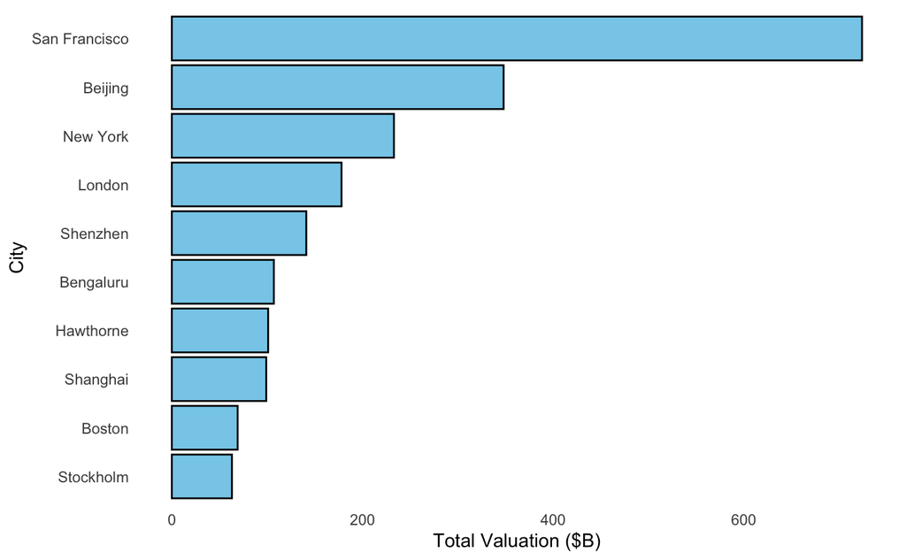

```r
city_valuation_summary <- companies_df %>%
  group_by(City) %>%
  summarise(total_valuation = sum(Valuation...B., na.rm = TRUE)) %>%
  arrange(desc(total_valuation))  # Arrange in descending order of total valuation

# Select the top 10 cities with the most valued startups
top_10_cities <- head(city_valuation_summary, 10)

# Reorder cities from highest to lowest total valuation
top_10_cities$City <- factor(top_10_cities$City, levels = rev(top_10_cities$City))

# Create a horizontal bar chart of the top 15 cities with no grids
ggplot(top_10_cities, aes(x = reorder(City, total_valuation), y = total_valuation)) +
  geom_bar(stat = "identity", fill = "skyblue", color = "black") +
  labs(x = "City", y = "Total Valuation ($B)") +
  theme_minimal() +
  theme(panel.grid.major = element_blank(), panel.grid.minor = element_blank()) +
  coord_flip()
```

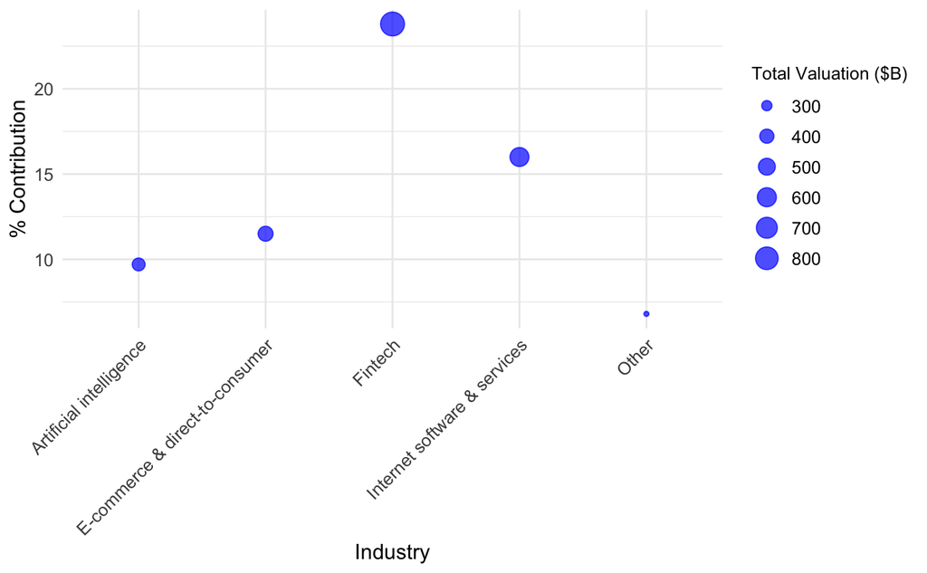

```r
# Estimate each industry's valuation contribution
industry_valuation_summary <- companies_df %>%
  group_by(Industry) %>%
  summarise(total_valuation = sum(Valuation...B., na.rm = TRUE),
            pct_contribution = round(total_valuation / sum(companies_df$Valuation...B., na.rm = TRUE) * 100, 1)) %>%
  arrange(desc(total_valuation)) %>%
  head(5)  # Select top 5 industries by total valuation contribution

# bubble chart
ggplot(industry_valuation_summary, aes(x = Industry, y = pct_contribution, size = total_valuation)) +
  geom_point(color = "blue", alpha = 0.7) +
  labs(x = "Industry", y = "% Contribution") +
  scale_size_continuous(name = "Total Valuation ($B)", labels = scales::comma) +
  theme_minimal() +
  theme(axis.text.x = element_text(angle = 45, hjust = 1),
        plot.title = element_text(size = 15),
        axis.title = element_text(size = 12),
        axis.text = element_text(size = 10),
        legend.title = element_text(size = 10),
        legend.text = element_text(size = 10))
```

##### Overall Valuation:

- The overall average Unicorn company valuation is about $3.455B

##### Valuation by country:

- The best performer here is Bahamas. It has one unicorn company FTX which is valued at $32B.
- Sweden is the next in line with an average valuation of $10.5B across its 6 unicorn companies. These are the only 2 countries that crossed the $10B mark in terms of average valuation.
- Croatia, Italy, and Czech Republic all come last on this list with an average unicorn valuation of $1B.

##### Valuation across Continents:

- North America, with $2.032 Trillion contributes ~54.75% of total valuation
- Asia, with $1.067 Trillion contributes ~28.75%
- Europe, with $503 Billion contributes ~13.55%
- Oceania, with $56 Billion contributes ~1.5%
- South America, with $48 Billion contributes ~ 1.29%
- Africa, with $5 Billion contributes ~0.13%

### Investor Analysis

#### 1. Average Valuation of Unicorn Companies by Number of Investors

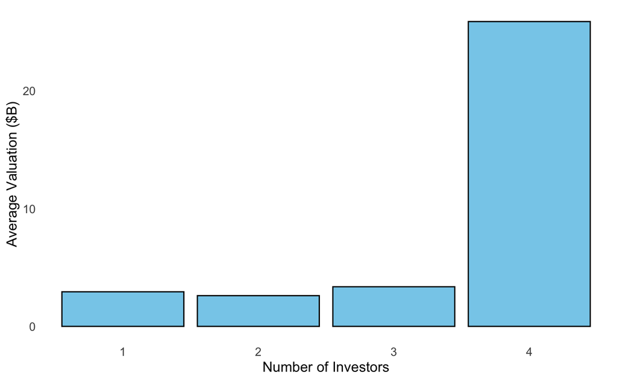

```r
avg_valuation_vs_investors <- companies_df %>%
  mutate(count_investors = str_count(Investors, "\\,") + 1) %>%  # Count number of investors
  group_by(count_investors) %>%
  summarise(average_valuation = mean(`Valuation...B.`, na.rm = TRUE)) %>%
  ungroup()

# Create a bar chart to show average valuation by number of investors
ggplot(avg_valuation_vs_investors, aes(x = factor(count_investors), y = average_valuation)) +
  geom_bar(stat = "identity", fill = "skyblue", color = "black") +
  scale_x_discrete(name = "Number of Investors") +
  scale_y_continuous(name = "Average Valuation ($B)", labels = scales::comma) +
  theme_minimal() +
  theme(axis.title = element_text(size = 12),
        axis.text = element_text(size = 10),
        panel.grid.major = element_blank(),
        panel.grid.minor = element_blank())
```

#### 2. Average correlation between Number of Investors and Average Valuation

```r
avg_valuation_vs_investors <- companies_df %>%
  mutate(count_investors = str_count(Investors, "\\,") + 1) %>%  # Count number of investors
  group_by(count_investors) %>%
  summarise(average_valuation = mean(`Valuation...B.`, na.rm = TRUE)) %>%
  ungroup()

# Calculate correlation between number of investors and average valuation
correlation <- cor(avg_valuation_vs_investors$count_investors, avg_valuation_vs_investors$average_valuation)
cat(correlation, "\n")
```

```
0.7839556
```

#### 3. Top 5 Investors and the number of companies they have invested in

```r
companies_df$Investors <- stringr::str_trim(companies_df$Investors)

# Count the number of companies each investor group is funding
investors_summary <- companies_df %>%
  separate_rows(Investors, sep = ",\\s*") %>%  # Separate multiple investors into rows
  mutate(Investors = stringr::str_trim(Investors)) %>%
  group_by(Investors) %>%
  summarise(total_companies = n_distinct(Company)) %>%
  arrange(desc(total_companies)) %>%
  head(5)

# Print the top 5 investors and the count of companies they are funding
print(investors_summary)
```

| Investors | total_companies |
| --- | --- |
| Accel | 60 |
| Tiger Global Management | 53 |
| Andreessen Horowitz | 52 |
| Sequoia Capital China | 48 |
| Insight Partners | 47 |

```r
NA
NA
```

#### 4. Further analysis can be conducted to understand the nature of investments each investor. Analyzing Accel.

```r
accel_investments <- companies_df %>%
  filter(grepl("Accel", Investors, ignore.case = TRUE))

# Summarize the number of companies Accel has invested in each industry
accel_industry_summary <- accel_investments %>%
  group_by(Industry) %>%
  summarise(total_companies = n()) %>%
  arrange(desc(total_companies))
print(accel_industry_summary)
```

| Industry | total_companies |
| --- | --- |
| Internet software & services | 20 |
| Fintech | 14 |
| E-commerce & direct-to-consumer | 9 |
| Cybersecurity | 5 |
| Supply chain, logistics, & delivery | 4 |
| Health | 3 |
| Artificial intelligence | 2 |
| Auto & transportation | 2 |
| Data management & analytics | 2 |
| Edtech | 2 |

[output cut: 3 more lines]

### Conclusion

1. Industry Dynamics:
- Fintech is the leading sector with the most unicorn companies, showing a strong trend towards tech-driven investments.
- Traditional industries have fewer unicorns, highlighting a focus on innovation.
2. Geographic Trends:
- North America has the highest number of unicorns, driven by strong tech ecosystems.
- Asia and Europe follow, showing a global spread of high-value startups.
- Africa has fewer unicorns but is showing growth.
3. Valuation Analysis:
- The average valuation of a unicorn company is around $3.45 billion.
- Countries like the Bahamas and Sweden have the highest average valuations.
4. Investor Influence:
- There is a strong positive correlation (0.78) between the number of investors and a company’s valuation.
- Companies with 4 investors have the highest average valuations, while those with 2 investors have the lowest.

### Recommendations

1. Industry Focus: Invest in the Fintech sector, which shows high growth and valuation potential.
2. Geographical Considerations: Target investments in regions with strong tech ecosystems, such as North America and Asia.
3. Investor Insights: Study the investment strategies of top investors like Accel, Andreessen Horowitz, and Tiger Global Management for better investment decisions.

By focusing on high-growth sectors, strategic locations, and understanding the impact of investor involvement, your company can make informed investment decisions and potentially identify future unicorns.